# Data 622 Homework 3: Palmer Penguins, Loan Approval Data EDA Analysis

Group 6: Alexander Ng, Scott Reed, Philip Tanofsky, Randall Thompson

Submitted by 04/09/2021

# Introduction

First, group has developed a system of checks and balances in preparing each model’s output. A primary and secondary author cross validate each model (pun intended) by independently coding and reconciling outputs. Two co-authors also bring a wider perspective on discussion and diagnostics. Afterwards, the primary author drafts the text for inclusion in this document.

Second, because four of the five sections deal with the Loan Approvals data, we decided to adopt a common dataset for all model analyses. Data wrangling and preparation are done once only. Consistency of the data in the last four parts is essential to assess model performance.

**Section 1** analyzes the Palmer Penguin dataset using the KNN model to predict `species`. The authors are Alexander Ng (primary) and Randy Thompson (secondary).

**Section 2** conducts an exploratory data analysis and defining the common data set for modeling. The authors are Randy Thompson (primary) with contributions by all other members.

**Section 3** analyzes the Loan Approvals by Decision Tree. The authors are Randy Thompson (primary) and Philip Tanofsky (secondary).

**Section 4** analyzes the same Loan Approvals with a Random Forest model. The authors are Scott Reed (primary) and Alexander Ng (secondary).

**Section 5** analyzes the same Loan Approvals with a Gradient Boosting approach. The authors are Philip Tanofsky (primary) and Scott Reed (secondary).

**Section 6** concludes with a discussion of the model performance and an appraisal of the merits of each result. We also consider the role of model driven prediction in a loan approvals business context.

**Section 7** presents our `R` code and technical appendices and references.

# 1 Penguins and the KNN algorithm

Following the data cleaning approach taken in prior assignments, we exclude observations where the feature `sex` is undefined. We also exclude the two variables `island` and `year` which do not seem helpful in prediction analysis. We follow the variable selection process described in a prior assignment [here](https://rpubs.com/Fixed_Point/728197).

## 1.1 Data Transformation for KNN

The next step is to normalize the data so that each quantitative variables have a mean zero and standard deviation equal to 1. However, we need to also include the `sex` variable in the K-nearest neighbor model. Normalization ensures that each variable has equal influence on the nearest neighbor calculation. Otherwise, a quantitative variable whose scale is much larger than the other variables would dominate the Euclidean distance calculation used in the KNN model.

However, we also need to include the `sex` variable as a feature in the KNN model. Categorical variables pose a challenge in the KNN context because they need to be mapped to a numerical equivalent. In the case of this data set, two facts are key:

1. the original data set gathered penguins by breeding pairs - thus the number of males and females is very balanced.
2. the variable is binary. Thus, two equal and opposite values can accomplish the goal of normalization.

## 1.2 Cross Validation and Parameter Tuning with KNN

We will use `caret` to test a range of possible values of $k$ and select the optimal $k$ based on minimizing the cross validation error. We did the pre-processing previously using `scale` so there is no need to invoke further data transformation inside `caret` pre-processing function calls.

`trainControl` allows us to define the training parameters.

`tuneLength` decides the range of allowed $k$ value to compute against the model.

We choose a 5-fold cross validation method to ensure the test set is sufficiently large.

## 1.3 KNN Model Output and Performance

To assess model performance and investigate the suitability of our choice of $k=5$, we consider two approaches. First we examine the statistical output of the confusion matrix. The accuracy and kappa ought to look attractive in the model selection. Second, we examine the smoothness of the decision boundary by plotting the decision boundary for $k=1$ and $k=5$. If the optimal $k$ shows a relatively smooth boundary, this is supporting evidence that the model parameters are reasonable.

First, we construct the confusion matrix of one specific implementation of the KNN model for the train-test split following the same proportions as the cross-validation study. We specifically use the `caret` interface rather than the simpler `class` interface to ensure consistency across multiple models in future.

Next, we visualize the decision boundary of our KNN model to check for model suitability. Custom code needs to be written as we are not aware if this plot type is currently provided by any R package.

# 2 Loan Approvals: Exploratory Data Analysis

## 2.1 Assessing the Raw Data

Our EDA shows the raw loan approvals dataset has varying level of quality.

Complete variables include: `Loan_ID`, `Education`, `Property_Area`, `Loan_Status`, `ApplicantIncome`, `CoapplicantIncome` Mostly complete variables include: `Married`, `Dependents`, `Loan_Amount_Term`, `Gender`

Variables with significant gaps include: `Self_Employed`, `LoanAmount`, `Credit_History` Of these variables, `Credit_History` is the most problematic and it influences the Loan Approval decision.

## 2.2 Defining a Common Dataset for Loan Approvals

In this section, we construct a common loan approval data which will be used for all of the model studies that follow. There are several steps that we take:

1. It consists solely of the records with no missing values for any relevant column and then exclude useless variables. We call this subset of observations. This reduces the number of observations from 614 to 480 which is a 78.2% of the original data set. While this is a significant reduction in the number of observations the remaining data is still sufficient for fitting models.

2. Next, we omit one irrelevant column: the `Loan_ID`. An identifier which is exogenous to the loan applicant and is assumed to be related solely to computer system processes.
3. Then we add a synthetic variable `Total_Income` which represents the sum of the `ApplicantIncome` and `CoapplicantIncome`.
4. We scale all quantitative variables to mean 0 and variance 1 variables with the `scale` function and retain both the nominal and scaled versions. The scaled variables are named like their nominal counterparts but prefixed with a lower case `s`. For example, `sApplicantIncome` has mean 0 and variance 1 whereas `ApplicantIncome` has the monthly nominal income.
5. Further, we convert the character type data columns from *text* to *factor*. This is importance for `Loan_Status` but also relevant for others like: `Credit_History`, `Property_Area`, `Gender`, `Married`, `Education`, `Self_Employed`. In addition, we convert `Dependents` from text to an ordered factor because the number of children is ordered.

Lastly, the common data set is exported to flat file. Each group member performs their Loan Approval model study by loading the common data set and making subsequent selections or transformations while retaining the same observations.

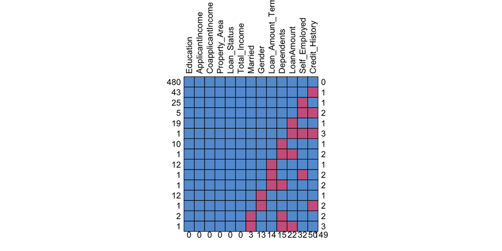

```
##     Education ApplicantIncome CoapplicantIncome Property_Area Loan_Status
## 480         1               1                 1             1           1
## 43          1               1                 1             1           1
## 25          1               1                 1             1           1
## 5           1               1                 1             1           1
## 19          1               1                 1             1           1
## 1           1               1                 1             1           1
## 10          1               1                 1             1           1
## 1           1               1                 1             1           1
## 12          1               1                 1             1           1
## 1           1               1                 1             1           1
## 1           1               1                 1             1           1
## 12          1               1                 1             1           1
## 1           1               1                 1             1           1
## 2           1               1                 1             1           1
```

[output cut: 36 more lines]

We see that we have some missing variables including a substantial run on Credit History. As this is likely to be a very important variable, has only two output states, and is not obviously derivable from the features provided, it is not a great candidate for imputation.

| Gender | Married | Dependents | Education | Self_Employed | ApplicantIncome | CoapplicantIncome | LoanAmount | Loan_Amount_Term | Credit_History | Property_Area | Loan_Status | Total_Income | sApplicantIncome | sCoapplicantIncome | sTotal_Income | sLoanAmount |
| --- | --- | --- | --- | --- | --- | --- | --- | --- | --- | --- | --- | --- | --- | --- | --- | --- |
| Male | Yes | 1 | Graduate | No | 4583 | 1508 | 128 | 360 | 1 | Rural | N | 6091 | -0.137825798 | -0.02792291 | -0.1431042 | -0.20787229 |
| Male | Yes | 0 | Graduate | Yes | 3000 | 0 | 66 | 360 | 1 | Urban | Y | 3000 | -0.417100645 | -0.60400285 | -0.6608641 | -0.97798052 |
| Male | Yes | 0 | Not Graduate | No | 2583 | 2358 | 120 | 360 | 1 | Urban | Y | 4941 | -0.490668308 | 0.29679058 | -0.3357357 | -0.30724110 |
| Male | No | 0 | Graduate | No | 6000 | 0 | 141 | 360 | 1 | Urban | Y | 6000 | 0.112163121 | -0.60400285 | -0.1583472 | -0.04639799 |
| Male | Yes | 2 | Graduate | Yes | 5417 | 4196 | 267 | 360 | 1 | Urban | Y | 9613 | 0.009309529 | 0.99893576 | 0.4468506 | 1.51866068 |
| Male | Yes | 0 | Not Graduate | No | 2333 | 1516 | 95 | 360 | 1 | Urban | Y | 3849 | -0.534773622 | -0.02486678 | -0.5186519 | -0.61776861 |

After exporting the common loan approval data, we load it into the R session and transform character string data to factors. This allows some R models to better handle response variables.

| Gender | Married | Dependents | Education | Self_Employed | ApplicantIncome | CoapplicantIncome | LoanAmount | Loan_Amount_Term | Credit_History | Property_Area | Loan_Status | Total_Income | sApplicantIncome | sCoapplicantIncome | sTotal_Income | sLoanAmount |
| --- | --- | --- | --- | --- | --- | --- | --- | --- | --- | --- | --- | --- | --- | --- | --- | --- |
| Male | Yes | 1 | Graduate | No | 4583 | 1508 | 128 | 360 | 1 | Rural | N | 6091 | -0.137825798 | -0.02792291 | -0.1431042 | -0.20787229 |
| Male | Yes | 0 | Graduate | Yes | 3000 | 0 | 66 | 360 | 1 | Urban | Y | 3000 | -0.417100645 | -0.60400285 | -0.6608641 | -0.97798052 |
| Male | Yes | 0 | Not Graduate | No | 2583 | 2358 | 120 | 360 | 1 | Urban | Y | 4941 | -0.490668308 | 0.29679058 | -0.3357357 | -0.30724110 |
| Male | No | 0 | Graduate | No | 6000 | 0 | 141 | 360 | 1 | Urban | Y | 6000 | 0.112163121 | -0.60400285 | -0.1583472 | -0.04639799 |
| Male | Yes | 2 | Graduate | Yes | 5417 | 4196 | 267 | 360 | 1 | Urban | Y | 9613 | 0.009309529 | 0.99893576 | 0.4468506 | 1.51866068 |
| Male | Yes | 0 | Not Graduate | No | 2333 | 1516 | 95 | 360 | 1 | Urban | Y | 3849 | -0.534773622 | -0.02486678 | -0.5186519 | -0.61776861 |

When performing modeling of common data set, each member may omit one of the Income variables to avoid multi-collinearity problems involving: `ApplicantIncome`, `CoapplicantIncome` and `Total_Income` or their scaled equivalents.

## 2.3 Conditional Approval Rates by Categorical Variable

One simple type of exploratory data analysis is to examine the conditional approval rates by values of each categorical variable $C$.  
For example, there are three subcategories (**Urban**, **Suburban**, **Rural**) of the variable `Property_Area`.  
If we find significant differences in the conditional loan approval rates between **Urban** and **Rural** applications, this suggests that `Property_Area` may help to predict approvals.

The conditional approval rates for each categorical variable is displayed below.

Loan Approved vs. Property_Area by Percent

|  | Rural | Semiurban | Urban |
| --- | --- | --- | --- |
| N (%) | 11.2 | 8.8 | 10.8 |
| Y (%) | 17.7 | 31.0 | 20.4 |
| Property_Area Column Total %: | 29.0 | 39.8 | 31.2 |
| Loan Approval Rate by Column% | 61.2 | 78.0 | 65.3 |
| Total Applications: | 139.0 | 191.0 | 150.0 |

Loan Approved vs. Credit_History by Percent

|  | 0 | 1 |
| --- | --- | --- |
| N (%) | 13.1 | 17.7 |
| Y (%) | 1.5 | 67.7 |
| Credit_History Column Total %: | 14.6 | 85.4 |
| Loan Approval Rate by Column% | 10.0 | 79.3 |
| Total Applications: | 70.0 | 410.0 |

Loan Approved vs. Loan_Amount_Term by Percent

|  | 36 | 60 | 84 | 120 | 180 | 240 | 300 | 360 | 480 |
| --- | --- | --- | --- | --- | --- | --- | --- | --- | --- |
| N (%) | 0.4 | 0.0 | 0.2 | 0.0 | 2.5 | 0.2 | 1.0 | 24.8 | 1.7 |
| Y (%) | 0.0 | 0.4 | 0.4 | 0.6 | 5.0 | 0.2 | 0.8 | 60.8 | 0.8 |
| Loan_Amount_Term Column Total %: | 0.4 | 0.4 | 0.6 | 0.6 | 7.5 | 0.4 | 1.9 | 85.6 | 2.5 |
| Loan Approval Rate by Column% | 0.0 | 100.0 | 66.7 | 100.0 | 66.7 | 50.0 | 44.4 | 71.0 | 33.3 |
| Total Applications: | 2.0 | 2.0 | 3.0 | 3.0 | 36.0 | 2.0 | 9.0 | 411.0 | 12.0 |

Loan Approved vs. Self_Employed by Percent

|  | No | Yes |
| --- | --- | --- |
| N (%) | 26.0 | 4.8 |
| Y (%) | 60.2 | 9.0 |
| Self_Employed Column Total %: | 86.2 | 13.8 |
| Loan Approval Rate by Column% | 69.8 | 65.2 |
| Total Applications: | 414.0 | 66.0 |

Loan Approved vs. Education by Percent

|  | Graduate | Not Graduate |
| --- | --- | --- |
| N (%) | 23.3 | 7.5 |
| Y (%) | 56.5 | 12.7 |
| Education Column Total %: | 79.8 | 20.2 |
| Loan Approval Rate by Column% | 70.8 | 62.9 |
| Total Applications: | 383.0 | 97.0 |

Loan Approved vs. Dependents by Percent

|  | 0 | 1 | 2 | 3+ |
| --- | --- | --- | --- | --- |
| N (%) | 18.1 | 5.8 | 4.2 | 2.7 |
| Y (%) | 39.0 | 10.8 | 13.5 | 5.8 |
| Dependents Column Total %: | 57.1 | 16.7 | 17.7 | 8.5 |
| Loan Approval Rate by Column% | 68.2 | 65.0 | 76.5 | 68.3 |
| Total Applications: | 274.0 | 80.0 | 85.0 | 41.0 |

Loan Approved vs. Married by Percent

|  | No | Yes |
| --- | --- | --- |
| N (%) | 13.3 | 17.5 |
| Y (%) | 21.9 | 47.3 |
| Married Column Total %: | 35.2 | 64.8 |
| Loan Approval Rate by Column% | 62.1 | 73.0 |
| Total Applications: | 169.0 | 311.0 |

Loan Approved vs. Gender by Percent

|  | Female | Male |
| --- | --- | --- |
| N (%) | 6.7 | 24.2 |
| Y (%) | 11.2 | 57.9 |
| Gender Column Total %: | 17.9 | 82.1 |
| Loan Approval Rate by Column% | 62.8 | 70.6 |
| Total Applications: | 86.0 | 394.0 |

We observe large differences in approval rates in the following categorical variables:

1. `Credit_History`: Those with credit history have 79.3% approval rate vs. 10.0% for those without.
2. `Property_Area`: `Rural` approval rates 61.2% are lower than `Semiurban` at 78.0%
3. `Married`: Unmarried applicant approval rate 62.1% is lower than for married at 73.0%
4. `Education`: `Not Graduate` approval rates 62.9% are lower than `Graduate` at 70.8%
5. `Gender`: Female applicant approval rate 62.8% is lower than for males at 70.6%.

These differences should suggest the most significant categorical variables for prediction purposes.